# Welcome to Ames, Iowa USA!

## Ames weather - temperature/precipitation

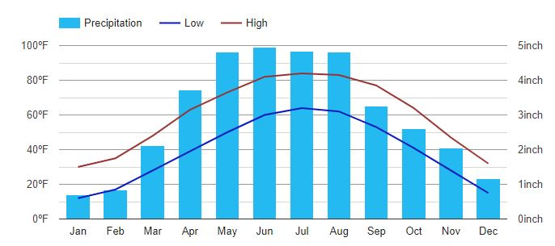

## Ames weather - winters

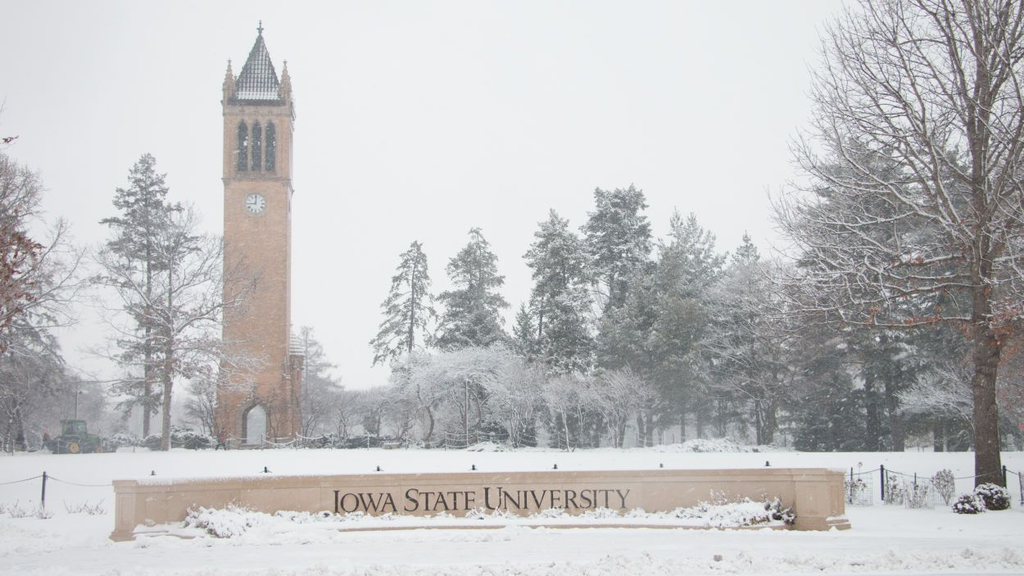

## [Snow emergency routes](https://www.cityofames.org/government/departments-divisions-i-z/public-works/operations/snow-ordinance-and-removal)

[figure not shown]

## Thunderstorms/tornados/derecho

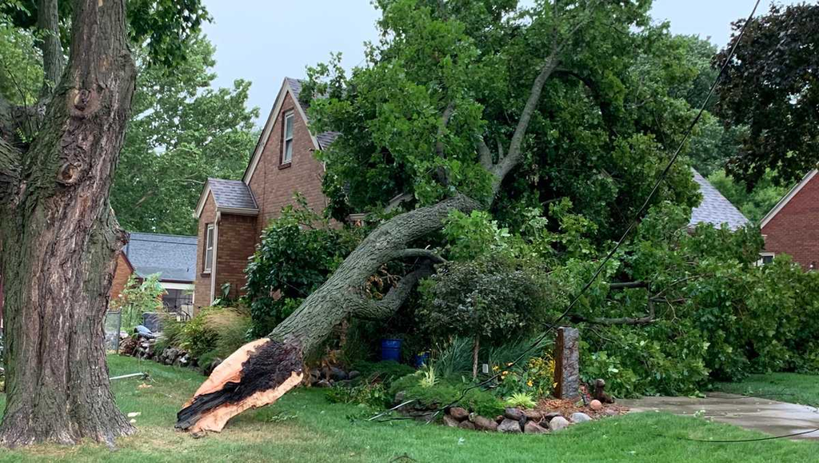

## [Story County Severe Weather Alert](https://www.storycountyiowa.gov/1155/Story-County-Iowa-Alerts)

- [Opt-In to Receive Severe Weather Alerts on your phone](https://www.storycountyiowa.gov/1155/Story-County-Iowa-Alerts)
- [siren test first Wednesday of every month at 10am](https://www.cityofames.org/Home/Components/Calendar/Event/8898/31)
- [Tornado Watch < Tornado Warning](https://www.weather.gov/safety/tornado-ww)

## What to do in Ames - All year

- [Ames Public Library](https://www.amespubliclibrary.org/)
- [Ames History Museum](https://ameshistory.org/)
- [Octagon Center for the Arts](https://octagonarts.org/)
- [Perfect Games](http://perfectgamesinc.com/PG/index.php/en/)
- [Seven Oaks Recreation](https://sevenoaksrec.com/)
- [Ames Community Theater](https://www.actorsinc.org/)
- [Iowa State Center](https://www.center.iastate.edu/events/)
- [Torrent Brewing Company](http://torrentbrewingco.com/), [Alluvial Brewing](https://www.alluvialbrewing.com/)
- [Prairie Moon Winery](https://prairiemoonwinery.com/)

## [Ames Parks and Recreation](https://www.cityofames.org/government/departments-divisions-i-z/parks-recreation)

[figure not shown]

## [Seven Oaks Recreation](https://sevenoaksrec.com/)

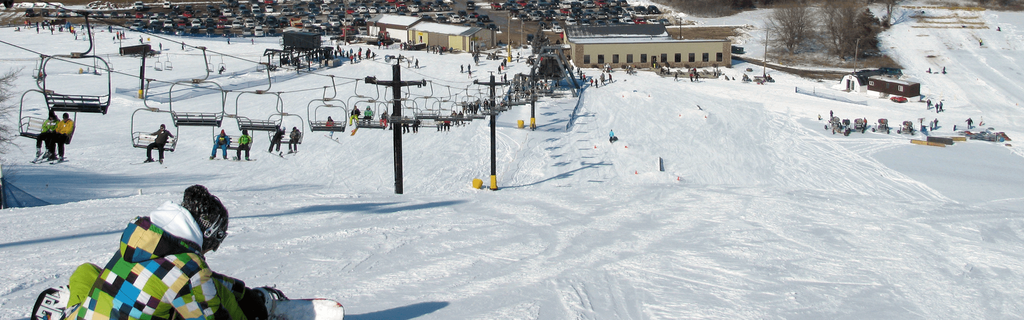

## Questions?

## Slides online

all orientation slides are available at

https://isustatistics.github.io/grad_orientation/

these slides are available at

https://isustatistics.github.io/grad_orientation/ames.html

provide updates by generating a pull request at

https://github.com/isustatistics/grad_orientation